# Intertwining of the Igf system and animal welfare

PCA analysis

Author

Anja Eggert, Anne-Marie Galow, et al.

Published

January 23, 2026

# 1 R Libraries

```r
library(tidyverse)     # tidy universe
library(readxl)        # read Excel files
library(kableExtra)    # html-table
library(rstatix)       # data summary
library(patchwork)     # combine plots
library(ggplotify)     # Converts base R plots to ggplot2 objects
library(mixOmics)      # PCA, PLS-DA
```

```r
set.seed(1989)
```

# 2 Imputed data

- many dropouts in data set due to different reasons
- data gaps were imputed with KNN method by Chaithra Umesh from Olaf Wolkenhauer’s group

# 3 Data

## 3.1 Read data

Data processing of the original done in file “igf-biomarker-summary-stats.qmd”.

```r
load("./data/data-processed.RData")
```

```r
dat.imp <- read_xlsx("./data/data-matrix.xlsx",
                 sheet = "data_imp",
                 col_names = TRUE,
                 na = c("", "n.A."),
                 .name_repair = "universal")
```

## 3.2 Data adjustments

```r
dat.ori <- dat.w
rm(dat.l, dat.w)
```

```r
dat.imp <- dat.imp |>
  # make factors
  mutate_at(vars(husbandry,
                 sow,
                 insem.group,
                 litter.no) , ~as.factor(.)) |>
  # molar ratio: IGFBP2=33.937 Da, IGFBP3=31.690 Da
  mutate(igfbp23.ser.105dpc = (igfbp2.ser.105dpc/33.937)/(igfbp3.ser.105dpc/31.690),
         igfbp23.ser.8dpp   = (igfbp2.ser.8dpp/33.937)/(igfbp3.ser.8dpp/31.690))   |>
  # unique identifier is combination of sow and litter
  mutate(id = as.factor(paste0(sow, ".", litter.no))) |>
  relocate(id, .after = litter.no)
```

Only keep those parameters in the original data set, where we have imputed data from:

```r
dat.ori <- dat.ori |>
  dplyr::select(intersect(names(dat.imp), names(dat.ori)))
```

# 4 Data summary

## 4.1 Original data

```r
dat.ori |>
  group_by(husbandry) |>
  rstatix::get_summary_stats(cort.sal.105dpc : stc1.8dpp, show = c("min", "max", "mean", "sd", "median", "q1", "q3")) |>
  ungroup() |>
  arrange(variable) |>
  kable(caption = "Summary statistics: original data") |>
  kable_styling(bootstrap_options = c("striped", "hover"),
                font_size = 10) |>
  scroll_box(width = "800px")
```

Summary statistics: original data

| husbandry | variable | n | min | max | mean | sd | median | q1 | q3 |
| --- | --- | --- | --- | --- | --- | --- | --- | --- | --- |
| conventional | cort.sal.105dpc | 9 | 0.959 | 25.956 | 11.765 | 8.423 | 10.585 | 6.734 | 16.984 |
| ecological | cort.sal.105dpc | 10 | 0.720 | 13.177 | 6.391 | 4.006 | 5.254 | 4.289 | 9.516 |
| conventional | cort.sal.8dpp | 10 | 0.872 | 12.599 | 4.648 | 3.454 | 3.813 | 2.775 | 5.113 |
| ecological | cort.sal.8dpp | 10 | 1.826 | 18.643 | 7.644 | 5.669 | 5.321 | 3.213 | 11.156 |
| conventional | bioact.ser.30dpc | 19 | 27.880 | 289.770 | 100.001 | 62.226 | 93.560 | 62.300 | 119.760 |
| ecological | bioact.ser.30dpc | 20 | 20.550 | 202.310 | 74.493 | 45.525 | 65.110 | 47.045 | 87.932 |
| conventional | bioact.ser.105dpc | 20 | 32.640 | 170.210 | 87.859 | 40.322 | 86.900 | 53.127 | 108.545 |
| ecological | bioact.ser.105dpc | 20 | 16.050 | 120.970 | 58.400 | 29.530 | 51.240 | 35.360 | 80.722 |
| conventional | bioact.ser.8dpp | 20 | 17.370 | 179.200 | 91.230 | 42.382 | 91.310 | 67.560 | 118.202 |
| ecological | bioact.ser.8dpp | 20 | 14.460 | 147.430 | 69.665 | 35.646 | 70.450 | 45.543 | 86.138 |
| conventional | igf2.ser.105dpc | 10 | 47.864 | 114.687 | 74.388 | 22.507 | 72.264 | 55.492 | 86.864 |
| ecological | igf2.ser.105dpc | 10 | 20.409 | 85.027 | 53.865 | 16.122 | 52.345 | 49.879 | 58.646 |
| conventional | igf2.ser.8dpp | 10 | 85.027 | 154.464 | 111.145 | 19.193 | 111.416 | 101.179 | 116.561 |
| ecological | igf2.ser.8dpp | 10 | 98.860 | 149.679 | 123.634 | 21.403 | 123.131 | 102.106 | 144.909 |
| conventional | igf1.ser.105dpc | 10 | 47.600 | 362.090 | 178.062 | 126.437 | 154.711 | 59.311 | 288.368 |
| ecological | igf1.ser.105dpc | 12 | 19.878 | 240.585 | 100.074 | 70.661 | 72.332 | 59.235 | 123.013 |
| conventional | igf1.ser.8dpp | 10 | 90.572 | 404.157 | 242.094 | 99.692 | 222.655 | 189.027 | 325.194 |
| ecological | igf1.ser.8dpp | 12 | 113.690 | 338.950 | 218.314 | 75.973 | 222.800 | 149.413 | 265.837 |
| conventional | igfbp2.ser.105dpc | 18 | 373.973 | 1045.104 | 698.904 | 198.165 | 668.462 | 555.817 | 818.291 |
| ecological | igfbp2.ser.105dpc | 18 | 208.951 | 1116.635 | 476.970 | 219.508 | 452.383 | 356.240 | 593.660 |
| conventional | igfbp2.ser.8dpp | 18 | 403.477 | 1249.212 | 684.564 | 245.442 | 593.279 | 501.262 | 784.047 |
| ecological | igfbp2.ser.8dpp | 18 | 191.881 | 1239.884 | 548.045 | 281.230 | 573.889 | 325.314 | 619.056 |
| conventional | igfbp3.ser.105dpc | 18 | 260.384 | 2454.638 | 1023.494 | 649.857 | 769.406 | 479.974 | 1572.000 |
| ecological | igfbp3.ser.105dpc | 18 | 307.531 | 4182.850 | 1183.896 | 1000.535 | 840.790 | 533.942 | 1408.016 |
| conventional | igfbp3.ser.8dpp | 18 | 304.793 | 4949.035 | 2084.462 | 1650.136 | 1573.588 | 751.844 | 3335.227 |
| ecological | igfbp3.ser.8dpp | 18 | 254.885 | 6396.586 | 2322.735 | 1916.329 | 1954.009 | 630.096 | 3682.049 |
| conventional | proteolysis.105dpc | 9 | 0.000 | 20.800 | 7.056 | 6.696 | 5.873 | 1.211 | 10.120 |
| ecological | proteolysis.105dpc | 10 | 0.000 | 17.597 | 6.917 | 7.320 | 5.688 | 0.000 | 13.444 |
| conventional | proteolysis.8dpp | 10 | 0.000 | 17.914 | 5.965 | 6.592 | 3.387 | 0.170 | 11.159 |
| ecological | proteolysis.8dpp | 10 | 0.000 | 13.294 | 6.906 | 5.365 | 8.115 | 1.433 | 11.171 |
| conventional | stc1.105dpc | 9 | 37.400 | 4672.325 | 1261.971 | 1845.193 | 142.269 | 78.413 | 2429.711 |
| ecological | stc1.105dpc | 10 | 152.634 | 8874.900 | 4321.316 | 3752.867 | 4643.253 | 673.275 | 7743.690 |
| conventional | stc1.8dpp | 9 | 35.318 | 2518.159 | 721.266 | 1026.408 | 102.547 | 49.893 | 1282.963 |
| ecological | stc1.8dpp | 10 | 87.496 | 9267.899 | 4249.235 | 4030.197 | 3167.642 | 517.456 | 8333.497 |

## 4.2 Imputed data

```r
dat.imp |>
  group_by(husbandry) |>
  rstatix::get_summary_stats(cort.sal.105dpc : stc1.8dpp, show = c("min", "max", "mean", "sd", "median", "q1", "q3")) |>
  ungroup() |>
  arrange(variable) |>
  kable(caption = "Summary statistics: imputed data") |>
  kable_styling(bootstrap_options = c("striped", "hover"),
                font_size = 10) |>
  scroll_box(width = "800px")
```

Summary statistics: imputed data

| husbandry | variable | n | min | max | mean | sd | median | q1 | q3 |
| --- | --- | --- | --- | --- | --- | --- | --- | --- | --- |
| conventional | cort.sal.105dpc | 20 | 0.959 | 58.139 | 16.940 | 12.532 | 16.338 | 9.110 | 23.679 |
| ecological | cort.sal.105dpc | 20 | 0.720 | 13.177 | 6.743 | 2.865 | 7.255 | 4.978 | 7.887 |
| conventional | cort.sal.8dpp | 20 | 0.872 | 12.599 | 4.583 | 2.494 | 3.873 | 3.540 | 5.414 |
| ecological | cort.sal.8dpp | 20 | 1.826 | 18.643 | 7.422 | 3.947 | 6.755 | 5.636 | 8.132 |
| conventional | bioact.ser.30dpc | 20 | 27.880 | 289.770 | 101.586 | 60.980 | 93.840 | 63.135 | 124.805 |
| ecological | bioact.ser.30dpc | 20 | 20.550 | 202.310 | 74.493 | 45.525 | 65.110 | 47.045 | 87.932 |
| conventional | bioact.ser.105dpc | 20 | 32.640 | 170.210 | 87.859 | 40.322 | 86.900 | 53.127 | 108.545 |
| ecological | bioact.ser.105dpc | 20 | 16.050 | 120.970 | 58.400 | 29.530 | 51.240 | 35.360 | 80.722 |
| conventional | bioact.ser.8dpp | 20 | 17.370 | 179.200 | 91.230 | 42.382 | 91.310 | 67.560 | 118.202 |
| ecological | bioact.ser.8dpp | 20 | 14.460 | 147.430 | 69.665 | 35.646 | 70.450 | 45.543 | 86.138 |
| conventional | igf2.ser.105dpc | 20 | 47.864 | 114.687 | 74.184 | 15.771 | 74.959 | 67.325 | 82.516 |
| ecological | igf2.ser.105dpc | 20 | 20.409 | 85.027 | 54.095 | 11.269 | 53.243 | 51.224 | 56.910 |
| conventional | igf2.ser.8dpp | 20 | 85.027 | 154.464 | 112.089 | 13.504 | 111.520 | 109.984 | 114.228 |
| ecological | igf2.ser.8dpp | 20 | 98.860 | 149.679 | 121.478 | 15.785 | 123.051 | 109.551 | 128.678 |
| conventional | igf1.ser.105dpc | 20 | 47.600 | 362.090 | 165.860 | 99.392 | 170.850 | 64.136 | 215.900 |
| ecological | igf1.ser.105dpc | 20 | 19.878 | 240.585 | 95.812 | 57.138 | 80.827 | 60.061 | 111.083 |
| conventional | igf1.ser.8dpp | 20 | 90.572 | 404.157 | 230.447 | 74.342 | 235.348 | 180.575 | 250.895 |
| ecological | igf1.ser.8dpp | 20 | 113.690 | 338.950 | 210.475 | 60.775 | 205.046 | 167.017 | 241.951 |
| conventional | igfbp2.ser.105dpc | 20 | 373.973 | 1045.104 | 698.190 | 188.638 | 668.462 | 589.912 | 782.048 |
| ecological | igfbp2.ser.105dpc | 20 | 208.951 | 1116.635 | 473.284 | 208.901 | 452.383 | 359.343 | 588.053 |
| conventional | igfbp2.ser.8dpp | 20 | 403.477 | 1249.212 | 684.638 | 232.279 | 630.409 | 507.490 | 760.779 |
| ecological | igfbp2.ser.8dpp | 20 | 191.881 | 1239.884 | 537.146 | 268.662 | 558.163 | 328.882 | 618.727 |
| conventional | igfbp3.ser.105dpc | 20 | 260.384 | 2454.638 | 1040.719 | 616.998 | 887.308 | 529.895 | 1461.517 |
| ecological | igfbp3.ser.105dpc | 20 | 307.531 | 4182.850 | 1234.428 | 961.714 | 860.740 | 542.653 | 1636.417 |
| conventional | igfbp3.ser.8dpp | 20 | 304.793 | 4949.035 | 2139.204 | 1570.585 | 1666.909 | 954.558 | 2964.249 |
| ecological | igfbp3.ser.8dpp | 20 | 254.885 | 6396.586 | 2396.147 | 1829.603 | 2144.197 | 726.796 | 3494.308 |
| conventional | proteolysis.105dpc | 20 | 0.000 | 20.800 | 8.056 | 4.598 | 9.032 | 6.724 | 10.153 |
| ecological | proteolysis.105dpc | 20 | 0.000 | 17.597 | 7.108 | 5.145 | 7.499 | 3.818 | 8.686 |
| conventional | proteolysis.8dpp | 20 | 0.000 | 17.914 | 5.317 | 4.752 | 3.703 | 2.775 | 7.082 |
| ecological | proteolysis.8dpp | 20 | 0.000 | 13.294 | 6.129 | 3.876 | 6.088 | 3.930 | 8.006 |
| conventional | stc1.105dpc | 20 | 37.400 | 8402.517 | 1710.187 | 2134.207 | 1031.951 | 80.408 | 2666.585 |
| ecological | stc1.105dpc | 20 | 152.634 | 8874.900 | 3947.616 | 2692.781 | 3588.754 | 2213.163 | 5515.530 |
| conventional | stc1.8dpp | 20 | 35.318 | 8630.404 | 1314.305 | 1976.374 | 654.234 | 64.777 | 2216.400 |
| ecological | stc1.8dpp | 20 | 87.496 | 9267.899 | 3852.894 | 2857.244 | 3445.941 | 2033.282 | 4547.348 |

# 5 Original vs. imputed data

## 5.1 Rearrange & combine data

```r
dat.ori.l <- dat.ori %>%
  pivot_longer(
    cols = -c(husbandry:id),
    names_to = c("parameter", "time"),
    names_pattern = "(.*)\\.(\\d+dpc|\\d+dpp)",
    values_to = "value.ori") |>
  mutate_at(vars(parameter,
                 time) , ~as.factor(.)) |>
  arrange(husbandry, parameter, time)
```

```r
dat.imp.l <- dat.imp %>%
  pivot_longer(
    cols = -c(husbandry:id),
    names_to = c("parameter", "time"),
    names_pattern = "(.*)\\.(\\d+dpc|\\d+dpp)",
    values_to = "value.imp") |>
  mutate_at(vars(parameter,
                 time) , ~as.factor(.)) |>
  arrange(husbandry, parameter, time)
```

```r
dat.l <- dat.imp.l |>
  dplyr::select(!c(husbandry, sow, insem.group, litter.no)) |>
  left_join(dat.ori.l, by = c("id", "parameter", "time")) |>
  pivot_longer(c(value.ori, value.imp),
               names_to = "datatype",
               values_to = "value") |>
  mutate(datatype = str_extract(datatype, "[^.]+$")) |>
  mutate_at(vars(datatype), ~as.factor(.)) |>
  arrange(parameter, time, datatype)
```

## 5.2 Plot

```r
# provide new labels as a named character vector:
# New facet label names for parameter variable
parameter.labs <- c("IGF bioactivity", "Cortisol (saliva)", "IGF1", "IGF2", "IGF BP2", "IGF BP3", "STC1")
names(parameter.labs) <- c("bioact.ser", "cort.sal", "igf1.ser", "igf2.ser", "igfbp2.ser", "igfbp3.ser", "stc1" )

# New facet label names for time variable
time.labs <- c("30dpc", "105dpc", "8dpp")
names(time.labs) <- c("30dpc", "105dpc", "8dpp")

plot <- dat.l |>
  mutate(time = fct_relevel(time, c("30dpc", "105dpc", "8dpp"))) |>
  # plot
  ggplot(aes(x = husbandry,
             y = value)) +
  geom_boxplot(aes(fill = datatype, col = datatype),
               position = position_dodge(width = 0.6),
               outlier.shape = NA,
               width = 0.3,
               linewidth = 0.2) +
  geom_jitter(aes(color = datatype),
              position = position_jitterdodge(jitter.width = 0.1, dodge.width = 0.6),
              shape = 4, size = 2) +
  scale_color_manual(values = c("grey70", "grey70"),
                     guide = "none") +
  scale_fill_manual(values = c("deepskyblue", "firebrick1"),
                    labels = c("original", "imputed")) +
  scale_x_discrete(labels = c("Conventional", "Ecological")) +
  labs(x = "Husbandry",
       y = "",
       fill = "Data set") +
  facet_grid(parameter ~ time,
             scales = "free_y",
             labeller = labeller(parameter = parameter.labs,
                                 time = time.labs)) +
  my_theme +
  theme(strip.text.y = element_text(angle = 0),
        strip.text.x = element_text(face = "bold", size = 14),
        legend.position = "bottom") +
  guides(fill = guide_legend(override.aes = list(linetype = 0, size  = 5)))
```

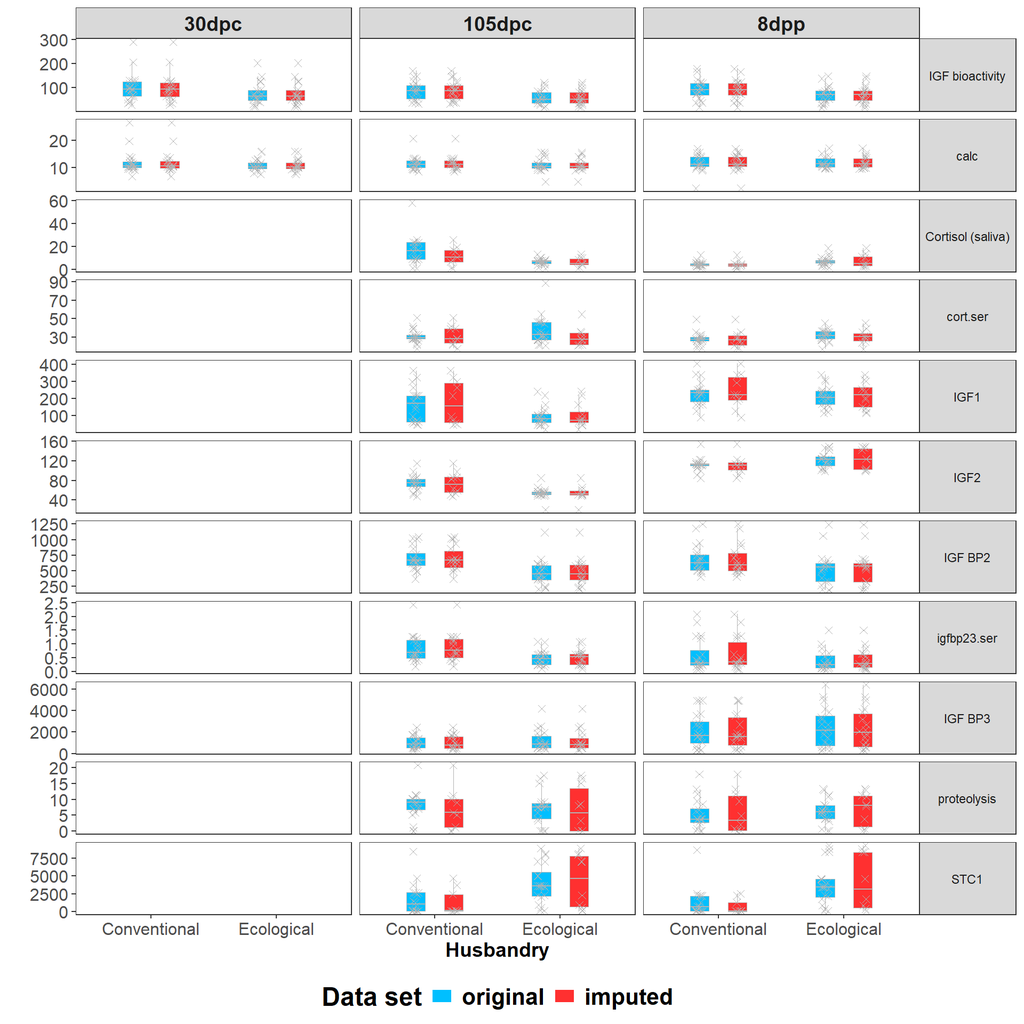

```r
plot
```

```r
png("./plots/ori-imp.png",
     width = 450, height = 300, units = "mm",
     pointsize = 10, res = 600)

plot
dev.off()
```

# 6 PCA - mit cort.ser

We use unsupervised PCA to explore data structure and to reduce dimensionality without assuming class differences. We also explore which variables contribute the most to explaining the variance in the data.

## 6.1 Original and imputed data

For the PCA we are only interested in following variables: serum cortisol, saliva cortisol, IGF bioactivity, IGF concentration, IGF protein, stanniocalcin concentration. They are 16 variables in total:

```r
vars.select <- c("cort.ser.105dpc", "cort.ser.8dpp",
                 "cort.sal.105dpc", "cort.sal.8dpp",
                 "bioact.ser.105dpc", "bioact.ser.8dpp",
                 "igf2.ser.105dpc", "igf2.ser.8dpp",
                 "igf1.ser.105dpc", "igf1.ser.8dpp",
                 "igfbp2.ser.105dpc", "igfbp2.ser.8dpp",
                 "igfbp3.ser.105dpc", "igfbp3.ser.8dpp",
                 "stc1.105dpc", "stc1.8dpp")
```

We only use complete cases of these 16 variables for the PCA. This are 8 conventional and 8 ecological data. In comparison, we have many more imputed data: 20 conventional and 20 ecological data sets.

```r
dat.ori.nonan <- dat.ori |>
  drop_na(vars.select) |>
  droplevels()
```

```r
dat.ori.nonan |>
  group_by(husbandry) |>
  # summary statistics of all numeric variables in the data frame is computed
  rstatix::get_summary_stats(show = c("min", "max", "mean", "sd", "median", "q1", "q3")) |>
  ungroup() |>
  arrange(variable) |>
  kable(caption = "Summary statistics: complete cases of original data") |>
  kable_styling(bootstrap_options = c("striped", "hover"),
                font_size = 10) |>
  scroll_box(width = "800px")
```

Summary statistics: complete cases of original data

| husbandry | variable | n | min | max | mean | sd | median | q1 | q3 |
| --- | --- | --- | --- | --- | --- | --- | --- | --- | --- |
| conventional | cort.ser.105dpc | 8 | 17.724 | 50.906 | 31.027 | 11.659 | 27.151 | 22.386 | 39.989 |
| ecological | cort.ser.105dpc | 8 | 20.891 | 54.719 | 31.607 | 10.831 | 29.242 | 25.340 | 35.034 |
| conventional | cort.ser.8dpp | 8 | 18.408 | 49.189 | 28.208 | 9.898 | 27.276 | 21.752 | 30.548 |
| ecological | cort.ser.8dpp | 8 | 24.200 | 45.243 | 31.809 | 7.186 | 30.323 | 27.620 | 33.421 |
| conventional | cort.sal.105dpc | 8 | 0.959 | 25.956 | 12.394 | 8.776 | 13.139 | 6.497 | 17.594 |
| ecological | cort.sal.105dpc | 8 | 0.720 | 13.177 | 6.715 | 4.119 | 5.254 | 4.469 | 10.087 |
| conventional | cort.sal.8dpp | 8 | 0.872 | 12.599 | 4.669 | 3.900 | 3.309 | 2.457 | 5.611 |
| ecological | cort.sal.8dpp | 8 | 2.458 | 18.643 | 8.798 | 5.770 | 8.193 | 4.236 | 12.032 |
| conventional | bioact.ser.30dpc | 8 | 60.630 | 289.770 | 128.525 | 78.837 | 96.445 | 87.465 | 138.282 |
| ecological | bioact.ser.30dpc | 8 | 50.050 | 202.310 | 95.126 | 49.034 | 80.710 | 68.172 | 99.985 |
| conventional | bioact.ser.105dpc | 8 | 42.110 | 170.210 | 100.956 | 44.606 | 93.330 | 73.440 | 131.988 |
| ecological | bioact.ser.105dpc | 8 | 33.340 | 120.970 | 74.058 | 31.459 | 72.450 | 49.500 | 91.598 |
| conventional | bioact.ser.8dpp | 8 | 45.060 | 165.920 | 99.415 | 37.252 | 97.710 | 74.585 | 119.905 |
| ecological | bioact.ser.8dpp | 8 | 48.000 | 147.430 | 91.058 | 36.782 | 81.530 | 67.328 | 114.590 |
| conventional | igf2.ser.105dpc | 8 | 47.864 | 114.687 | 75.695 | 23.494 | 72.264 | 58.193 | 89.631 |
| ecological | igf2.ser.105dpc | 8 | 48.759 | 85.027 | 58.574 | 12.100 | 53.243 | 51.224 | 61.803 |
| conventional | igf2.ser.8dpp | 8 | 85.027 | 154.464 | 111.075 | 21.519 | 111.416 | 97.476 | 115.862 |
| ecological | igf2.ser.8dpp | 8 | 98.860 | 149.679 | 120.679 | 22.265 | 113.315 | 101.409 | 143.004 |
| conventional | igf1.ser.105dpc | 8 | 47.600 | 322.416 | 140.222 | 109.849 | 84.030 | 53.445 | 227.402 |
| ecological | igf1.ser.105dpc | 8 | 41.896 | 240.585 | 119.593 | 77.004 | 80.827 | 65.375 | 178.297 |
| conventional | igf1.ser.8dpp | 8 | 90.572 | 404.157 | 232.127 | 105.833 | 210.806 | 171.098 | 302.621 |
| ecological | igf1.ser.8dpp | 8 | 113.690 | 338.950 | 222.485 | 80.742 | 222.800 | 177.132 | 268.323 |
| conventional | igfbp2.ser.105dpc | 8 | 487.930 | 1023.213 | 708.742 | 206.317 | 671.789 | 579.489 | 777.155 |
| ecological | igfbp2.ser.105dpc | 8 | 225.115 | 685.931 | 405.909 | 163.049 | 363.777 | 327.738 | 448.257 |
| conventional | igfbp2.ser.8dpp | 8 | 403.477 | 749.145 | 533.182 | 105.851 | 504.376 | 473.153 | 582.510 |
| ecological | igfbp2.ser.8dpp | 8 | 191.881 | 618.562 | 416.137 | 187.847 | 426.370 | 252.214 | 591.998 |
| conventional | igfbp3.ser.105dpc | 8 | 260.384 | 2454.638 | 956.517 | 768.501 | 691.795 | 411.370 | 1183.919 |
| ecological | igfbp3.ser.105dpc | 8 | 343.634 | 2531.138 | 954.797 | 813.569 | 538.297 | 492.019 | 1062.851 |
| conventional | igfbp3.ser.8dpp | 8 | 304.793 | 4922.471 | 2013.781 | 1802.643 | 1491.166 | 343.690 | 3581.540 |
| ecological | igfbp3.ser.8dpp | 8 | 254.885 | 4151.401 | 1419.755 | 1386.847 | 808.469 | 497.179 | 2024.955 |
| conventional | proteolysis.105dpc | 4 | 1.211 | 20.800 | 10.848 | 8.013 | 10.690 | 7.893 | 13.644 |
| ecological | proteolysis.105dpc | 4 | 0.000 | 16.578 | 6.280 | 7.959 | 4.272 | 0.000 | 10.553 |
| conventional | proteolysis.8dpp | 5 | 0.000 | 13.132 | 5.460 | 5.800 | 4.760 | 0.000 | 9.411 |
| ecological | proteolysis.8dpp | 4 | 3.842 | 11.283 | 8.573 | 3.411 | 9.584 | 7.210 | 10.947 |
| conventional | stc1.105dpc | 8 | 37.400 | 4672.325 | 1401.934 | 1920.843 | 122.509 | 69.113 | 2750.131 |
| ecological | stc1.105dpc | 8 | 152.634 | 8874.900 | 4265.280 | 3800.252 | 4643.253 | 486.191 | 7267.047 |
| conventional | stc1.8dpp | 8 | 35.318 | 2518.159 | 797.517 | 1069.679 | 99.091 | 47.543 | 1526.004 |
| ecological | stc1.8dpp | 8 | 87.496 | 9267.899 | 4158.803 | 4107.228 | 3167.642 | 318.185 | 8435.440 |
| conventional | calc.30dpc | 8 | 9.486 | 26.527 | 13.635 | 6.165 | 10.659 | 10.283 | 13.560 |
| ecological | calc.30dpc | 8 | 8.686 | 15.808 | 11.133 | 2.316 | 10.244 | 9.884 | 11.672 |
| conventional | calc.105dpc | 8 | 9.341 | 20.599 | 12.468 | 3.528 | 11.952 | 10.723 | 12.575 |
| ecological | calc.105dpc | 8 | 4.857 | 15.509 | 10.911 | 3.313 | 10.672 | 10.103 | 11.982 |
| conventional | calc.8dpp | 8 | 10.126 | 15.329 | 12.254 | 1.931 | 11.645 | 10.739 | 13.907 |
| ecological | calc.8dpp | 8 | 9.486 | 15.210 | 12.327 | 2.045 | 12.433 | 11.023 | 13.757 |
| conventional | igfbp23.ser.105dpc | 8 | 0.385 | 2.432 | 1.005 | 0.638 | 0.868 | 0.628 | 1.115 |
| ecological | igfbp23.ser.105dpc | 8 | 0.190 | 1.083 | 0.543 | 0.278 | 0.543 | 0.396 | 0.630 |
| conventional | igfbp23.ser.8dpp | 8 | 0.097 | 1.787 | 0.668 | 0.662 | 0.295 | 0.185 | 1.239 |
| ecological | igfbp23.ser.8dpp | 8 | 0.115 | 0.993 | 0.491 | 0.324 | 0.439 | 0.261 | 0.707 |

```r
var.ori <- dat.ori.nonan |>
  dplyr::select(vars.select) |>
  # rename columns
  rename(`Cortisol 105dpc (serum)`  = cort.ser.105dpc,
         `Cortisol 8dpp (serum)`    = cort.ser.8dpp,
         `Cortisol 105dpc (saliva)` = cort.sal.105dpc,
         `Cortisol 8dpp (saliva)`   = cort.sal.8dpp,
         `IGF Bioactivity 105dpc`   = bioact.ser.105dpc,
         `IGF Bioactivity 8dpp`     = bioact.ser.8dpp,
         `IGF2 105dpc`              = igf2.ser.105dpc,
         `IGF2 8dpp`                = igf2.ser.8dpp,
         `IGF1 105dpc`              = igf1.ser.105dpc,
         `IGF1 8dpp`                = igf1.ser.8dpp,
         `IGF BP2 105dpc`           = igfbp2.ser.105dpc,
         `IGF BP2 8dpp`             = igfbp2.ser.8dpp,
         `IGF BP3 105dpc`           = igfbp3.ser.105dpc,
         `IGF BP3 8dpp`             = igfbp3.ser.8dpp,
         `STC1 105dpc`              = stc1.105dpc,
         `STC1 8dpp`                = stc1.8dpp)
```

```r
var.imp <- dat.imp |>
  dplyr::select(vars.select) |>
  # rename columns
  rename(`Cortisol 105dpc (serum)`  = cort.ser.105dpc,
         `Cortisol 8dpp (serum)`    = cort.ser.8dpp,
         `Cortisol 105dpc (saliva)` = cort.sal.105dpc,
         `Cortisol 8dpp (saliva)`   = cort.sal.8dpp,
         `IGF Bioactivity 105dpc`   = bioact.ser.105dpc,
         `IGF Bioactivity 8dpp`     = bioact.ser.8dpp,
         `IGF2 105dpc`              = igf2.ser.105dpc,
         `IGF2 8dpp`                = igf2.ser.8dpp,
         `IGF1 105dpc`              = igf1.ser.105dpc,
         `IGF1 8dpp`                = igf1.ser.8dpp,
         `IGF BP2 105dpc`           = igfbp2.ser.105dpc,
         `IGF BP2 8dpp`             = igfbp2.ser.8dpp,
         `IGF BP3 105dpc`           = igfbp3.ser.105dpc,
         `IGF BP3 8dpp`             = igfbp3.ser.8dpp,
         `STC1 105dpc`              = stc1.105dpc,
         `STC1 8dpp`                = stc1.8dpp)
```

We have repeated measurements per sow, but multilevel analysis can only be performed when all samples are repeated at least once. `multilevel = dat.imp$sow.no` not possible here.

```r
table(dat.ori.nonan$sow)
```

```
6733 6734 6738 6740 6791 6794 6843 6845 6876 6877 6943 6949
   2    1    1    2    1    2    1    1    1    2    1    1
```

```r
table(dat.imp$sow)
```

```
6733 6734 6738 6740 6791 6794 6843 6845 6876 6877 6899 6903 6924 6943 6949
   3    3    3    3    3    3    3    2    3    3    3    1    3    3    1
```

## 6.2 Run PCA

```r
# run the method, centering + scaling?
pca.ori <- mixOmics::pca(var.ori,
                         center = TRUE, scale = TRUE,
                         ncomp = 4)
pca.imp <- mixOmics::pca(var.imp,
                         center = TRUE, scale = TRUE,
                         ncomp = 4)
```

### 6.2.1 Individuals plots

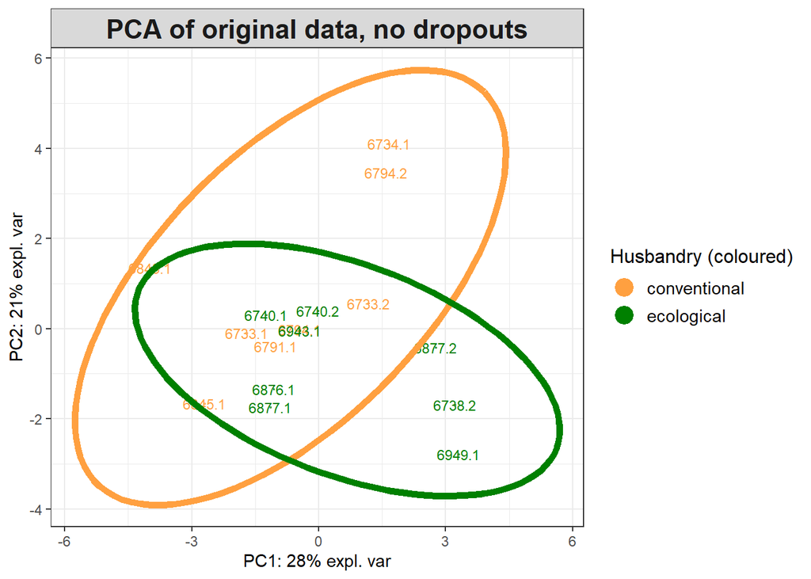

```r
plotIndiv(pca.ori,
          comp         = c(1, 2),   # Specify PCs to plot
          ind.names    = dat.ori.nonan$id,
          group        = dat.ori.nonan$husbandry,
          title        = 'PCA of original data, no dropouts',
          legend       = TRUE,
          legend.title = 'Husbandry (coloured)',
          col = c("#FFA040", "#008000"),
          ellipse = TRUE,
          point.lwd = 2, cex = 3)
```

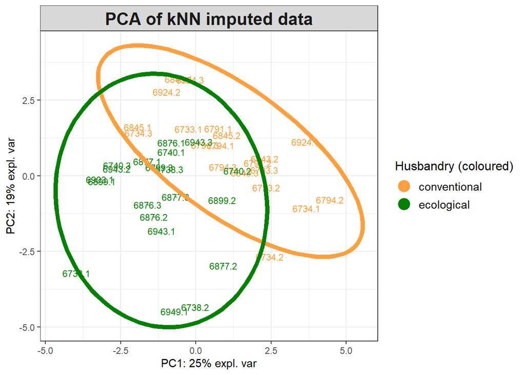

```r
plotIndiv(pca.imp,
          comp         = c(1, 2),   # Specify PCs to plot
          ind.names    = dat.imp$id,
          group        = dat.imp$husbandry,
          title        = 'PCA of kNN imputed data',
          legend       = TRUE,
          legend.title = 'Husbandry (coloured)',
          col = c("#FFA040", "#008000"),
          ellipse = TRUE,
          point.lwd = 2, cex = 3)
```

### 6.2.2 Biplots

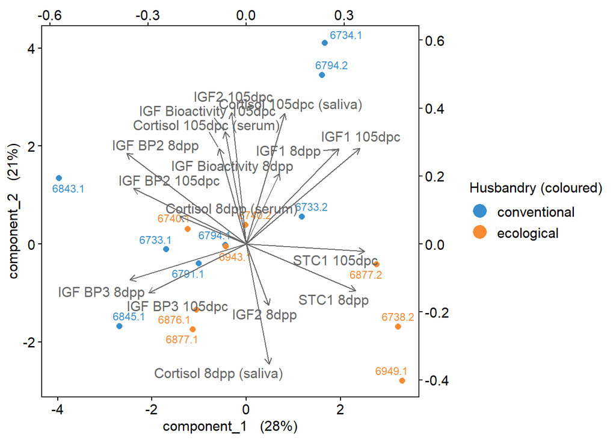

```r
biplot(pca.ori,
       group        = dat.ori.nonan$husbandry,
       ind.names    = dat.ori.nonan$id, # not Show row names of samples
       legend       = TRUE,
       legend.title = 'Husbandry (coloured)',
       col          = c("#FFA040", "#008000"))
```

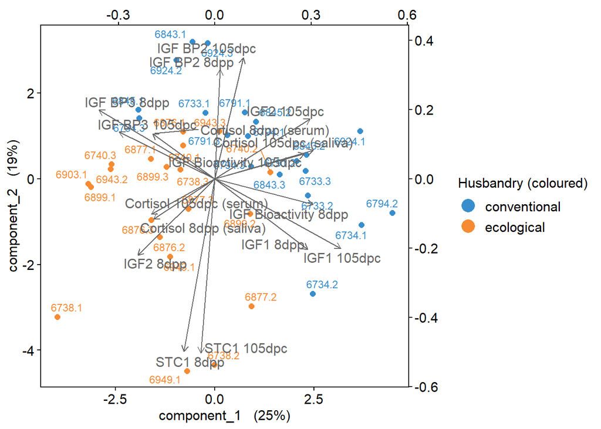

```r
biplot(pca.imp,
       group        = dat.imp$husbandry,
       ind.names    = dat.imp$id, # not Show row names of samples
       legend       = TRUE,
       legend.title = 'Husbandry (coloured)',
       col          = c("#FFA040", "#008000"))
```

### 6.2.3 Loadings

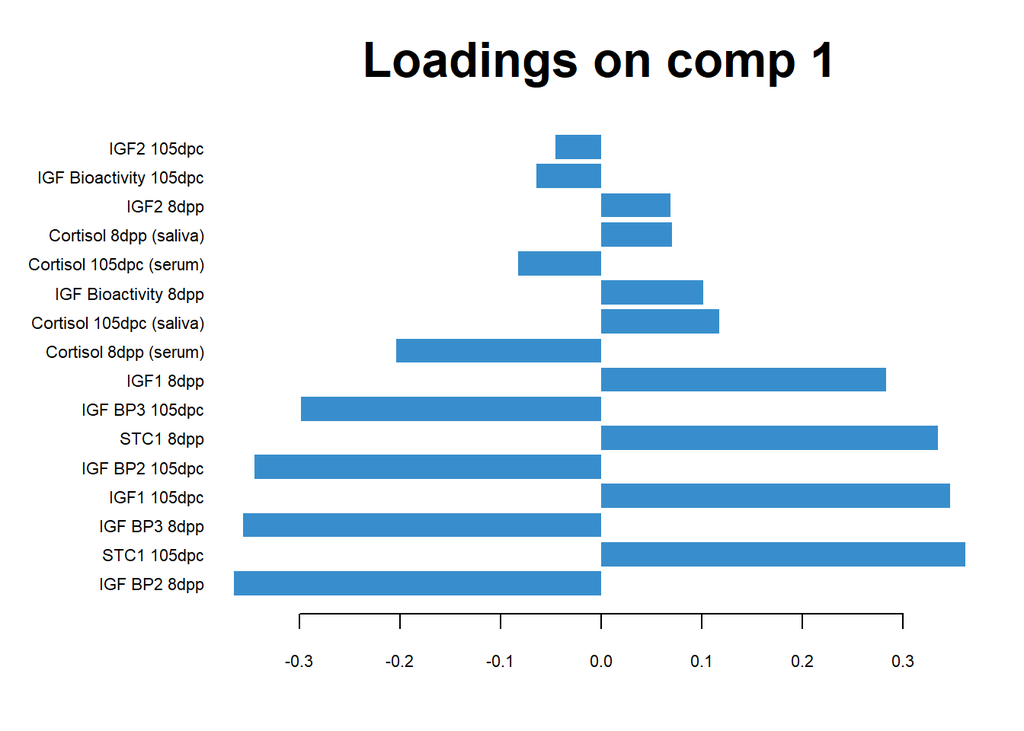

```r
plotLoadings(pca.ori, comp = 1)
```

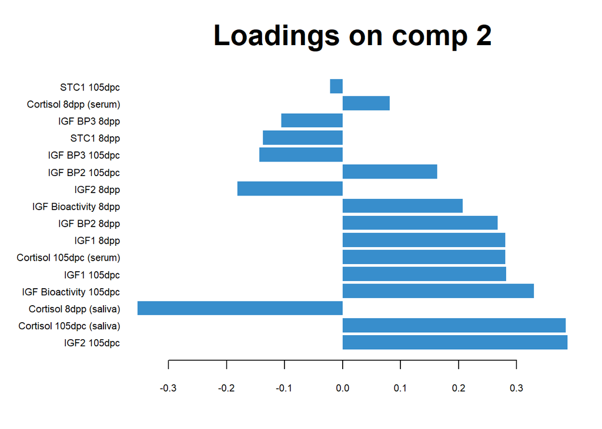

```r
plotLoadings(pca.ori, comp = 2)
```

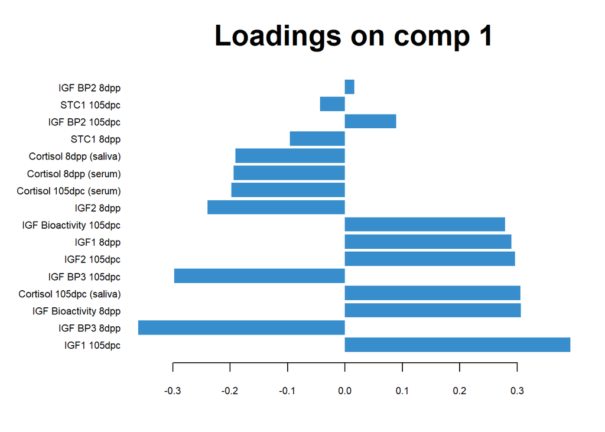

```r
plotLoadings(pca.imp, comp = 1)
```

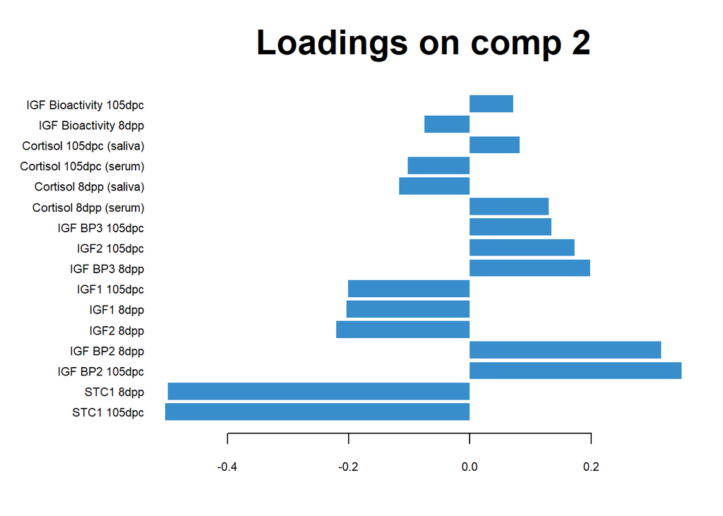

```r
plotLoadings(pca.imp, comp = 2)
```

## 6.3 Plot loadings

Prepare data frame:

```r
load.ori <- bind_cols(as_tibble(pca.ori$loadings$X),
                      as_tibble(pca.ori$names$X)) |>
  rename(parameter = value) |>
  dplyr::select(parameter, PC1, PC2) |>
  pivot_longer(!parameter, names_to = "PCs", values_to = "loading") |>
  # make factors
  mutate_at(vars(parameter,
                 PCs) , ~as.factor(.)) |>
  group_by(PCs) |>
  slice_max(order_by = abs(loading), n = 5) |>
  ungroup() |>
  droplevels()

# duplicated "IGF1 105dpc"
# make parameter to character
load.ori <- load.ori |>
  mutate_at(vars(parameter) , ~as.character(.))

load.ori$parameter[load.ori$parameter == "IGF1 105dpc" &
                   load.ori$PCs == "PC1"] <- "IGF1 105dpc_PC1"

load.ori$parameter[load.ori$parameter == "IGF1 105dpc" &
                   load.ori$PCs == "PC2"] <- "IGF1 105dpc_PC2"

# make parameter back to factor
load.ori <- load.ori |>
  mutate_at(vars(parameter) , ~as.factor(.))

# Change order of `PCs` factor levels
load.ori$PCs <- factor(load.ori$PCs, levels = c("PC1", "PC2"))
# Reorder `parameter` based on `PCs` (PC1 first, PC2 second)
load.ori$parameter <- factor(load.ori$parameter,
                             levels = load.ori$parameter[order(load.ori$PCs)])
```

```r
load.imp <- bind_cols(as_tibble(pca.imp$loadings$X),
                      as_tibble(pca.imp$names$X)) |>
  rename(parameter = value) |>
  dplyr::select(parameter, PC1, PC2) |>
  pivot_longer(!parameter, names_to = "PCs", values_to = "loading") |>
  # make factors
  mutate_at(vars(parameter,
                 PCs) , ~as.factor(.)) |>
  group_by(PCs) |>
  slice_max(order_by = abs(loading), n = 5) |>
  ungroup() |>
  droplevels()

# Change order of `PCs` factor levels
load.imp$PCs <- factor(load.imp$PCs, levels = c("PC1", "PC2"))
# Reorder `parameter` based on `PCs` (PC1 first, PC2 second)
load.imp$parameter <- factor(load.imp$parameter,
                             levels = load.imp$parameter[order(load.imp$PCs)])
```

Loading plots:

```r
plot.load.ori <- load.ori |>
  ggplot(aes(x = parameter, y = loading, fill = PCs)) +
  geom_bar(stat     = "identity", width = 0.7,
           position = position_identity()) +
  geom_vline(xintercept = 5.5) +
  scale_fill_manual(values = c("PC1" = "dodgerblue", "PC2" = "dodgerblue4"),
                    guide  = "none") +
  scale_x_discrete(lim = rev) +
  scale_y_continuous(lim = c(-0.55, 0.55),
                     breaks = seq(-0.5, 0.5, 0.1)) +
  labs(x    = NULL,
       y    = "Loading",
       fill = NULL) +
  geom_text(x = 1,  y = 0.4, label = "PC2",
            size = 16/.pt, color = "dodgerblue4") +
  geom_text(x = 10, y = 0.4, label = "PC1",
            size = 16/.pt, color = "dodgerblue") +
  my_theme_load +
  theme(aspect.ratio = 0.6) +
  coord_flip()
```

```r
plot.load.imp <- load.imp |>
  ggplot(aes(x = parameter, y = loading, fill = PCs)) +
  geom_bar(stat     = "identity", width = 0.7,
           position = position_identity()) +
  geom_vline(xintercept = 5.5) +
  scale_fill_manual(values = c("PC1" = "dodgerblue", "PC2" = "dodgerblue4"), guide="none") +
  scale_x_discrete(lim = rev) +
  scale_y_continuous(lim = c(-0.55, 0.55),
                     breaks = seq(-0.5, 0.5, 0.1)) +
  labs(x    = NULL,
       y    = "Loading",
       fill = NULL) +
  geom_text(x = 1,  y = -0.4, label = "PC2",
            size = 16/.pt, color = "dodgerblue4") +
  geom_text(x = 10, y = -0.4, label = "PC1",
            size = 16/.pt, color = "dodgerblue") +
  my_theme_load +
  theme(aspect.ratio = 0.6) +
  coord_flip()
```

## 6.4 Combined plots

Convert plotIndiv() output to ggplot2 objects:

```r
plot.ori <- as.ggplot(~ plotIndiv(pca.ori,
                                  comp         = c(1, 2),   # Specify PCs to plot
                                  #ind.names    = dat.ori.nonan$id,
                                  pch          = 16,
                                  group        = dat.ori.nonan$husbandry,
                                  title        = 'Original data',
                                  X.label =c(expression(paste("PC 1 (28%)"))),
                                  Y.label =c(expression(paste("PC 2 (21%)"))),
                                  legend       = FALSE,
                                  legend.title = 'Husbandry',
                                  col = c("#FFA040", "#008000"),
                                  ellipse = TRUE,
                                  ellipse.level = 0.90,
                                  cex = 3,
                                  size.title  = rel(1.1),
                                  size.label  = rel(1),
                                  size.axis   = rel(0.8),
                                  size.legend = rel(1),
                                  xlim = c(-6,6),
                                  ylim = c(-6,6),
                                  style = 'ggplot2'))+
  theme(aspect.ratio = 1/1)
```

```r
plot.imp <- as.ggplot(~ plotIndiv(pca.imp,
                                  comp         = c(1, 2),   # Specify PCs to plot
                                  #ind.names    = dat.imp$id,
                                  pch          = 16,
                                  group        = dat.imp$husbandry,
                                  title        = 'Imputed data',
                                  X.label =c(expression(paste("PC 1 (25%)"))),
                                  Y.label =c(expression(paste("PC 2 (19%)"))),
                                  legend       = FALSE,
                                  legend.title = 'Husbandry',
                                  col = c("#FFA040", "#008000"),
                                  ellipse = TRUE,
                                  ellipse.level = 0.95,
                                  cex = 3,
                                  size.title  = rel(1.1),
                                  size.label  = rel(1),
                                  size.axis   = rel(0.8),
                                  size.legend = rel(1),
                                  xlim = c(-6,6),
                                  ylim = c(-6,6),
                                  style = 'ggplot2'))+
  theme(aspect.ratio = 1/1)
```

```r
combined <- (free(plot.ori, side = "l") +
             free(plot.imp, side = "l") +
             plot.load.ori +
             plot.load.imp) +
  plot_layout(heights = c(2, 1)) +
  plot_annotation(tag_levels = 'A') &
  theme(plot.tag = element_text(size = 16))
```

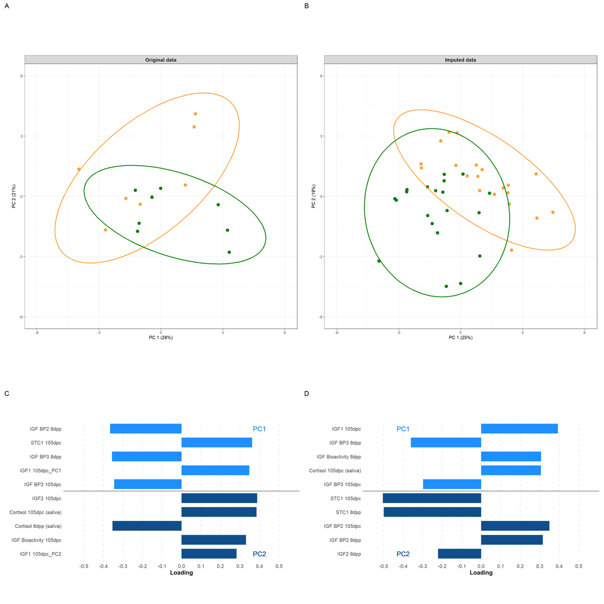

```r
combined
```

# 7 PCA - ohne cort.ser

We use unsupervised PCA to explore data structure and to reduce dimensionality without assuming class differences. We also explore which variables contribute the most to explaining the variance in the data.

## 7.1 Original and imputed data

For the PCA we are only interested in following variables: saliva cortisol, IGF bioactivity, IGF concentration, IGF protein, stanniocalcin concentration. They are 14 variables in total:

```r
vars.select <- c("cort.sal.105dpc", "cort.sal.8dpp",
                 "bioact.ser.105dpc", "bioact.ser.8dpp",
                 "igf2.ser.105dpc", "igf2.ser.8dpp",
                 "igf1.ser.105dpc", "igf1.ser.8dpp",
                 "igfbp2.ser.105dpc", "igfbp2.ser.8dpp",
                 "igfbp3.ser.105dpc", "igfbp3.ser.8dpp",
                 "stc1.105dpc", "stc1.8dpp")
```

```r
dat.ori.nonan <- dat.ori |>
  drop_na(vars.select) |>
  droplevels()
```

```r
dat.ori.nonan |>
  group_by(husbandry) |>
  # summary statistics of all numeric variables in the data frame is computed
  rstatix::get_summary_stats(show = c("min", "max", "mean", "sd", "median", "q1", "q3")) |>
  ungroup() |>
  arrange(variable) |>
  kable(caption = "Summary statistics: complete cases of original data") |>
  kable_styling(bootstrap_options = c("striped", "hover"),
                font_size = 10) |>
  scroll_box(width = "800px")
```

Summary statistics: complete cases of original data

| husbandry | variable | n | min | max | mean | sd | median | q1 | q3 |
| --- | --- | --- | --- | --- | --- | --- | --- | --- | --- |
| conventional | cort.ser.105dpc | 8 | 17.724 | 50.906 | 31.027 | 11.659 | 27.151 | 22.386 | 39.989 |
| ecological | cort.ser.105dpc | 8 | 20.891 | 54.719 | 31.607 | 10.831 | 29.242 | 25.340 | 35.034 |
| conventional | cort.ser.8dpp | 8 | 18.408 | 49.189 | 28.208 | 9.898 | 27.276 | 21.752 | 30.548 |
| ecological | cort.ser.8dpp | 9 | 24.200 | 45.243 | 32.181 | 6.813 | 31.037 | 28.506 | 35.152 |
| conventional | cort.sal.105dpc | 8 | 0.959 | 25.956 | 12.394 | 8.776 | 13.139 | 6.497 | 17.594 |
| ecological | cort.sal.105dpc | 9 | 0.720 | 13.177 | 6.899 | 3.893 | 5.547 | 4.559 | 9.896 |
| conventional | cort.sal.8dpp | 8 | 0.872 | 12.599 | 4.669 | 3.900 | 3.309 | 2.457 | 5.611 |
| ecological | cort.sal.8dpp | 9 | 1.826 | 18.643 | 8.023 | 5.876 | 5.951 | 2.874 | 11.397 |
| conventional | bioact.ser.30dpc | 8 | 60.630 | 289.770 | 128.525 | 78.837 | 96.445 | 87.465 | 138.282 |
| ecological | bioact.ser.30dpc | 9 | 50.050 | 202.310 | 100.731 | 48.852 | 86.760 | 71.250 | 125.590 |
| conventional | bioact.ser.105dpc | 8 | 42.110 | 170.210 | 100.956 | 44.606 | 93.330 | 73.440 | 131.988 |
| ecological | bioact.ser.105dpc | 9 | 21.050 | 120.970 | 68.168 | 34.324 | 62.490 | 46.020 | 84.910 |
| conventional | bioact.ser.8dpp | 8 | 45.060 | 165.920 | 99.415 | 37.252 | 97.710 | 74.585 | 119.905 |
| ecological | bioact.ser.8dpp | 9 | 48.000 | 147.430 | 90.080 | 34.531 | 82.260 | 72.020 | 106.830 |
| conventional | igf2.ser.105dpc | 8 | 47.864 | 114.687 | 75.695 | 23.494 | 72.264 | 58.193 | 89.631 |
| ecological | igf2.ser.105dpc | 9 | 20.409 | 85.027 | 54.333 | 17.028 | 53.243 | 50.551 | 60.446 |
| conventional | igf2.ser.8dpp | 8 | 85.027 | 154.464 | 111.075 | 21.519 | 111.416 | 97.476 | 115.862 |
| ecological | igf2.ser.8dpp | 9 | 98.860 | 149.679 | 123.689 | 22.701 | 123.131 | 101.641 | 145.861 |
| conventional | igf1.ser.105dpc | 8 | 47.600 | 322.416 | 140.222 | 109.849 | 84.030 | 53.445 | 227.402 |
| ecological | igf1.ser.105dpc | 9 | 19.878 | 240.585 | 108.514 | 79.330 | 75.761 | 63.527 | 165.049 |
| conventional | igf1.ser.8dpp | 8 | 90.572 | 404.157 | 232.127 | 105.833 | 210.806 | 171.098 | 302.621 |
| ecological | igf1.ser.8dpp | 9 | 113.690 | 338.950 | 214.648 | 79.101 | 205.015 | 151.954 | 254.417 |
| conventional | igfbp2.ser.105dpc | 8 | 487.930 | 1023.213 | 708.742 | 206.317 | 671.789 | 579.489 | 777.155 |
| ecological | igfbp2.ser.105dpc | 9 | 225.115 | 685.931 | 387.069 | 162.654 | 360.895 | 246.890 | 392.969 |
| conventional | igfbp2.ser.8dpp | 8 | 403.477 | 749.145 | 533.182 | 105.851 | 504.376 | 473.153 | 582.510 |
| ecological | igfbp2.ser.8dpp | 9 | 191.881 | 618.562 | 437.830 | 187.379 | 522.074 | 270.948 | 611.371 |
| conventional | igfbp3.ser.105dpc | 8 | 260.384 | 2454.638 | 956.517 | 768.501 | 691.795 | 411.370 | 1183.919 |
| ecological | igfbp3.ser.105dpc | 9 | 343.634 | 2531.138 | 942.916 | 761.858 | 547.008 | 494.273 | 847.864 |
| conventional | igfbp3.ser.8dpp | 8 | 304.793 | 4922.471 | 2013.781 | 1802.643 | 1491.166 | 343.690 | 3581.540 |
| ecological | igfbp3.ser.8dpp | 9 | 254.885 | 4151.401 | 1690.133 | 1529.988 | 1035.191 | 572.858 | 2687.814 |
| conventional | proteolysis.105dpc | 4 | 1.211 | 20.800 | 10.848 | 8.013 | 10.690 | 7.893 | 13.644 |
| ecological | proteolysis.105dpc | 5 | 0.000 | 16.578 | 6.636 | 6.938 | 8.056 | 0.000 | 8.544 |
| conventional | proteolysis.8dpp | 5 | 0.000 | 13.132 | 5.460 | 5.800 | 4.760 | 0.000 | 9.411 |
| ecological | proteolysis.8dpp | 5 | 0.000 | 11.283 | 6.859 | 4.840 | 8.332 | 3.842 | 10.836 |
| conventional | stc1.105dpc | 8 | 37.400 | 4672.325 | 1401.934 | 1920.843 | 122.509 | 69.113 | 2750.131 |
| ecological | stc1.105dpc | 9 | 152.634 | 8874.900 | 4693.446 | 3779.763 | 7013.157 | 573.649 | 7982.012 |
| conventional | stc1.8dpp | 8 | 35.318 | 2518.159 | 797.517 | 1069.679 | 99.091 | 47.543 | 1526.004 |
| ecological | stc1.8dpp | 9 | 87.496 | 9267.899 | 4623.072 | 4086.632 | 4592.343 | 395.041 | 8337.218 |
| conventional | calc.30dpc | 8 | 9.486 | 26.527 | 13.635 | 6.165 | 10.659 | 10.283 | 13.560 |
| ecological | calc.30dpc | 9 | 8.686 | 15.928 | 11.666 | 2.692 | 10.299 | 9.940 | 13.293 |
| conventional | calc.105dpc | 8 | 9.341 | 20.599 | 12.468 | 3.528 | 11.952 | 10.723 | 12.575 |
| ecological | calc.105dpc | 9 | 4.857 | 15.509 | 11.249 | 3.261 | 10.686 | 10.377 | 13.952 |
| conventional | calc.8dpp | 8 | 10.126 | 15.329 | 12.254 | 1.931 | 11.645 | 10.739 | 13.907 |
| ecological | calc.8dpp | 9 | 9.486 | 17.186 | 12.866 | 2.506 | 13.293 | 11.384 | 14.072 |
| conventional | igfbp23.ser.105dpc | 8 | 0.385 | 2.432 | 1.005 | 0.638 | 0.868 | 0.628 | 1.115 |
| ecological | igfbp23.ser.105dpc | 9 | 0.190 | 1.083 | 0.511 | 0.277 | 0.475 | 0.260 | 0.616 |
| conventional | igfbp23.ser.8dpp | 8 | 0.097 | 1.787 | 0.668 | 0.662 | 0.295 | 0.185 | 1.239 |
| ecological | igfbp23.ser.8dpp | 9 | 0.115 | 0.993 | 0.453 | 0.324 | 0.320 | 0.148 | 0.663 |

```r
var.ori <- dat.ori.nonan |>
  dplyr::select(vars.select) |>
  # rename columns
  rename(`Cortisol 105dpc (saliva)` = cort.sal.105dpc,
         `Cortisol 8dpp (saliva)`   = cort.sal.8dpp,
         `IGF Bioactivity 105dpc`   = bioact.ser.105dpc,
         `IGF Bioactivity 8dpp`     = bioact.ser.8dpp,
         `IGF2 105dpc`              = igf2.ser.105dpc,
         `IGF2 8dpp`                = igf2.ser.8dpp,
         `IGF1 105dpc`              = igf1.ser.105dpc,
         `IGF1 8dpp`                = igf1.ser.8dpp,
         `IGF BP2 105dpc`           = igfbp2.ser.105dpc,
         `IGF BP2 8dpp`             = igfbp2.ser.8dpp,
         `IGF BP3 105dpc`           = igfbp3.ser.105dpc,
         `IGF BP3 8dpp`             = igfbp3.ser.8dpp,
         `STC1 105dpc`              = stc1.105dpc,
         `STC1 8dpp`                = stc1.8dpp)
```

```r
var.imp <- dat.imp |>
  dplyr::select(vars.select) |>
  # rename columns
  rename(`Cortisol 105dpc (saliva)` = cort.sal.105dpc,
         `Cortisol 8dpp (saliva)`   = cort.sal.8dpp,
         `IGF Bioactivity 105dpc`   = bioact.ser.105dpc,
         `IGF Bioactivity 8dpp`     = bioact.ser.8dpp,
         `IGF2 105dpc`              = igf2.ser.105dpc,
         `IGF2 8dpp`                = igf2.ser.8dpp,
         `IGF1 105dpc`              = igf1.ser.105dpc,
         `IGF1 8dpp`                = igf1.ser.8dpp,
         `IGF BP2 105dpc`           = igfbp2.ser.105dpc,
         `IGF BP2 8dpp`             = igfbp2.ser.8dpp,
         `IGF BP3 105dpc`           = igfbp3.ser.105dpc,
         `IGF BP3 8dpp`             = igfbp3.ser.8dpp,
         `STC1 105dpc`              = stc1.105dpc,
         `STC1 8dpp`                = stc1.8dpp)
```

We have repeated measurements per sow, but multilevel analysis can only be performed when all samples are repeated at least once. `multilevel = dat.imp$sow.no` not possible here.

```r
table(dat.ori.nonan$sow)
```

```
6733 6734 6738 6740 6791 6794 6843 6845 6876 6877 6943 6949
   2    1    2    2    1    2    1    1    1    2    1    1
```

```r
table(dat.imp$sow)
```

```
6733 6734 6738 6740 6791 6794 6843 6845 6876 6877 6899 6903 6924 6943 6949
   3    3    3    3    3    3    3    2    3    3    3    1    3    3    1
```

## 7.2 Run PCA

```r
# run the method, centering + scaling?
pca.ori <- mixOmics::pca(var.ori,
                         center = TRUE, scale = TRUE,
                         ncomp = 4)
pca.imp <- mixOmics::pca(var.imp,
                         center = TRUE, scale = TRUE,
                         ncomp = 4)
```

### 7.2.1 Individuals plots

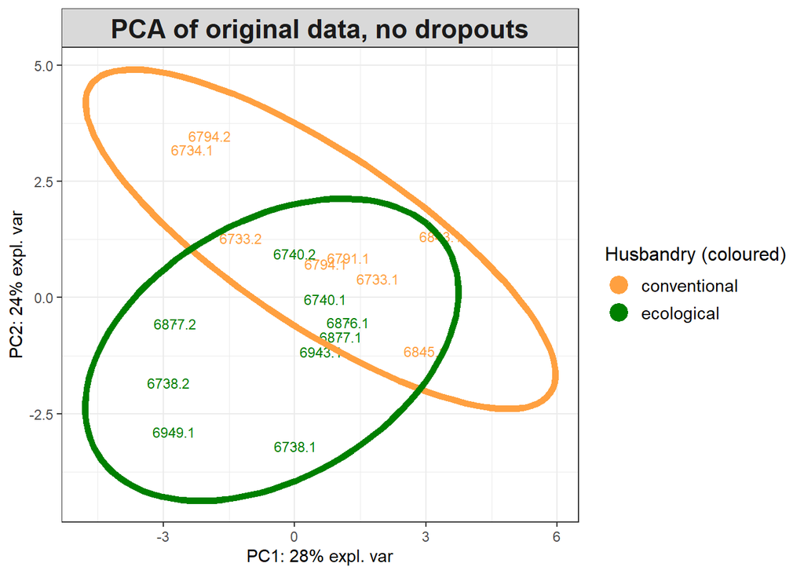

```r
plotIndiv(pca.ori,
          comp         = c(1, 2),   # Specify PCs to plot
          ind.names    = dat.ori.nonan$id,
          group        = dat.ori.nonan$husbandry,
          title        = 'PCA of original data, no dropouts',
          legend       = TRUE,
          legend.title = 'Husbandry (coloured)',
          col = c("#FFA040", "#008000"),
          ellipse = TRUE,
          point.lwd = 2, cex = 3)
```

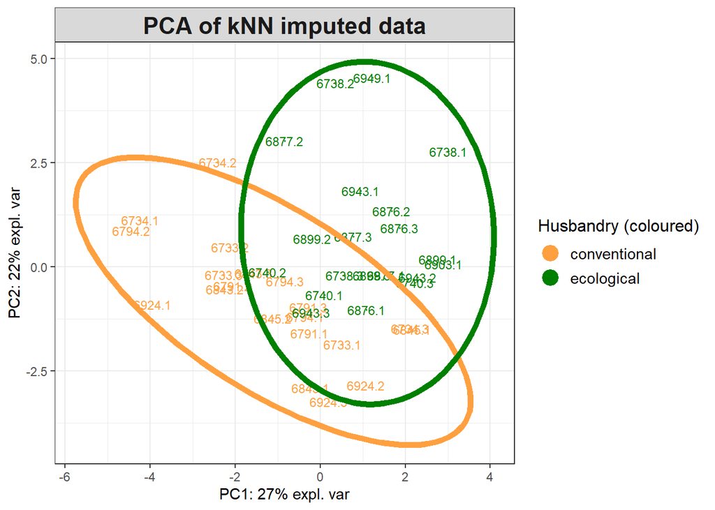

```r
plotIndiv(pca.imp,
          comp         = c(1, 2),   # Specify PCs to plot
          ind.names    = dat.imp$id,
          group        = dat.imp$husbandry,
          title        = 'PCA of kNN imputed data',
          legend       = TRUE,
          legend.title = 'Husbandry (coloured)',
          col = c("#FFA040", "#008000"),
          ellipse = TRUE,
          point.lwd = 2, cex = 3)
```

### 7.2.2 Biplots

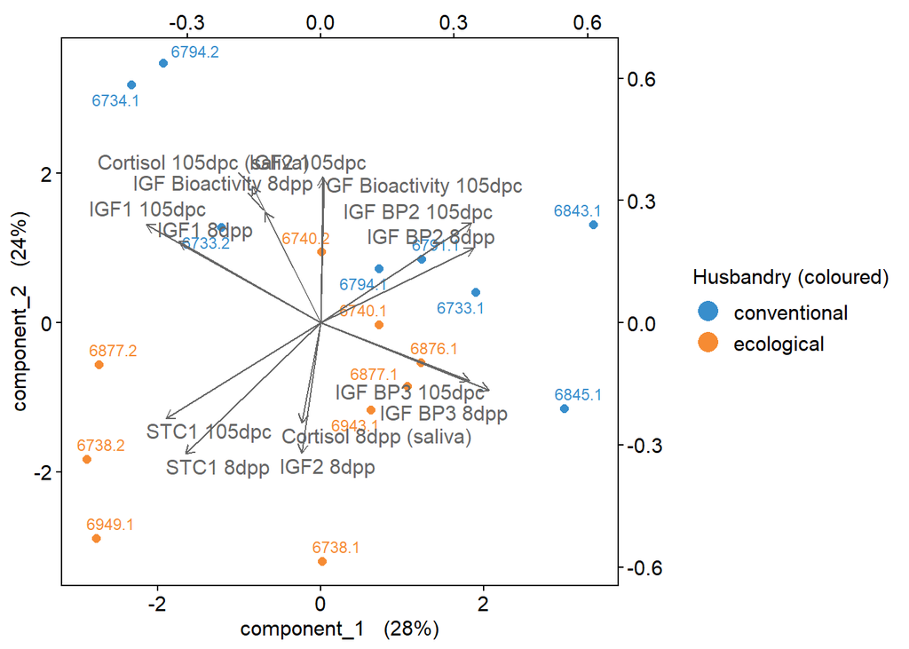

```r
biplot(pca.ori,
       group        = dat.ori.nonan$husbandry,
       ind.names    = dat.ori.nonan$id, # not Show row names of samples
       legend       = TRUE,
       legend.title = 'Husbandry (coloured)',
       col          = c("#FFA040", "#008000"))
```

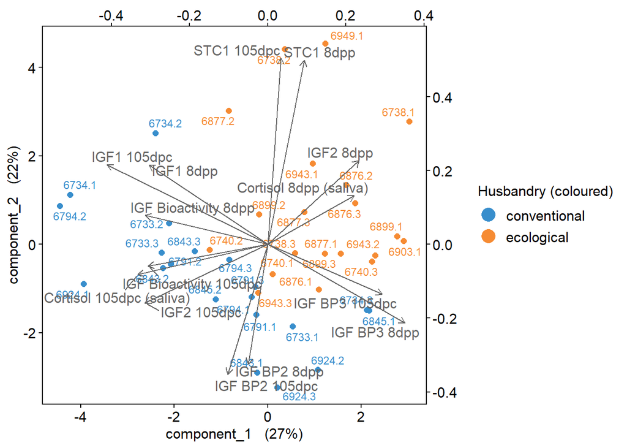

```r
biplot(pca.imp,
       group        = dat.imp$husbandry,
       ind.names    = dat.imp$id, # not Show row names of samples
       legend       = TRUE,
       legend.title = 'Husbandry (coloured)',
       col          = c("#FFA040", "#008000"))
```

### 7.2.3 Loadings

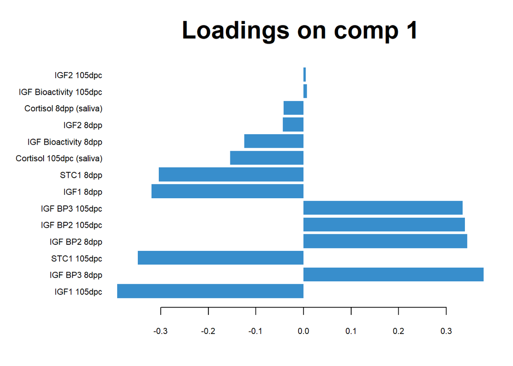

```r
plotLoadings(pca.ori, comp = 1)
```

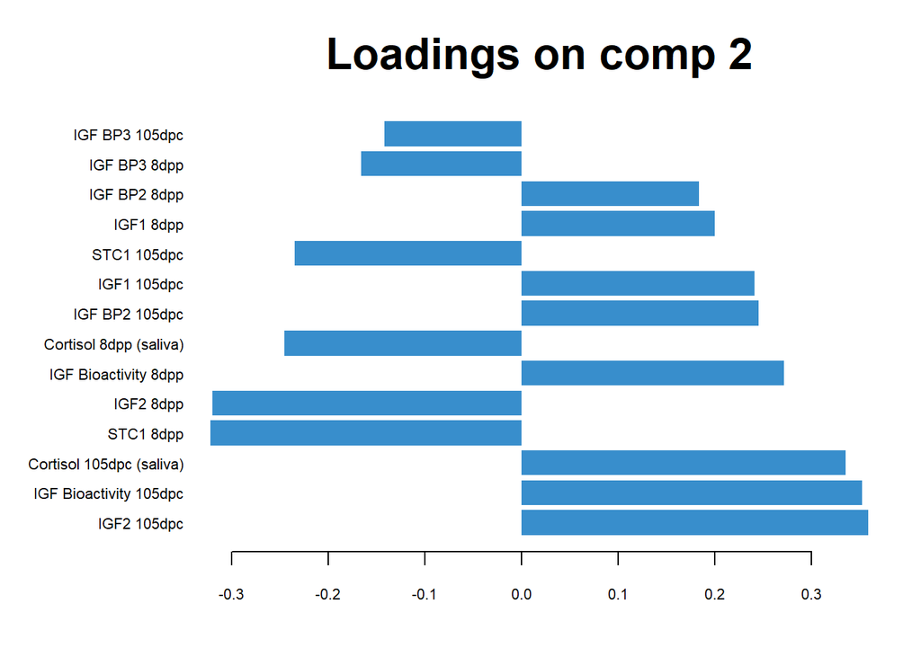

```r
plotLoadings(pca.ori, comp = 2)
```

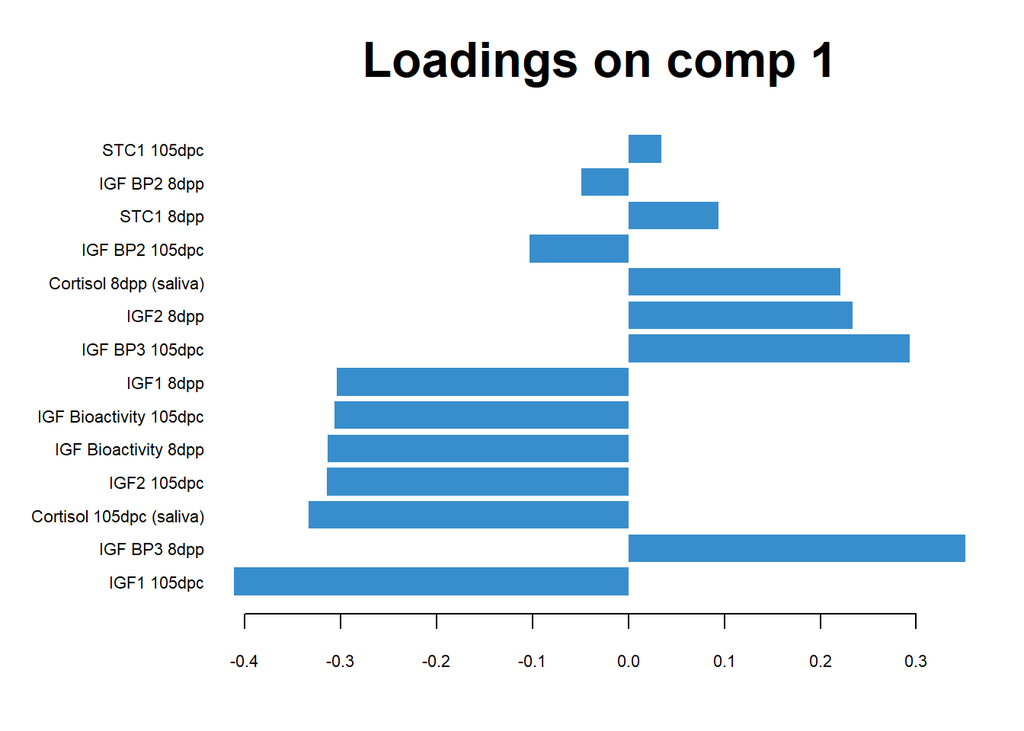

```r
plotLoadings(pca.imp, comp = 1)
```

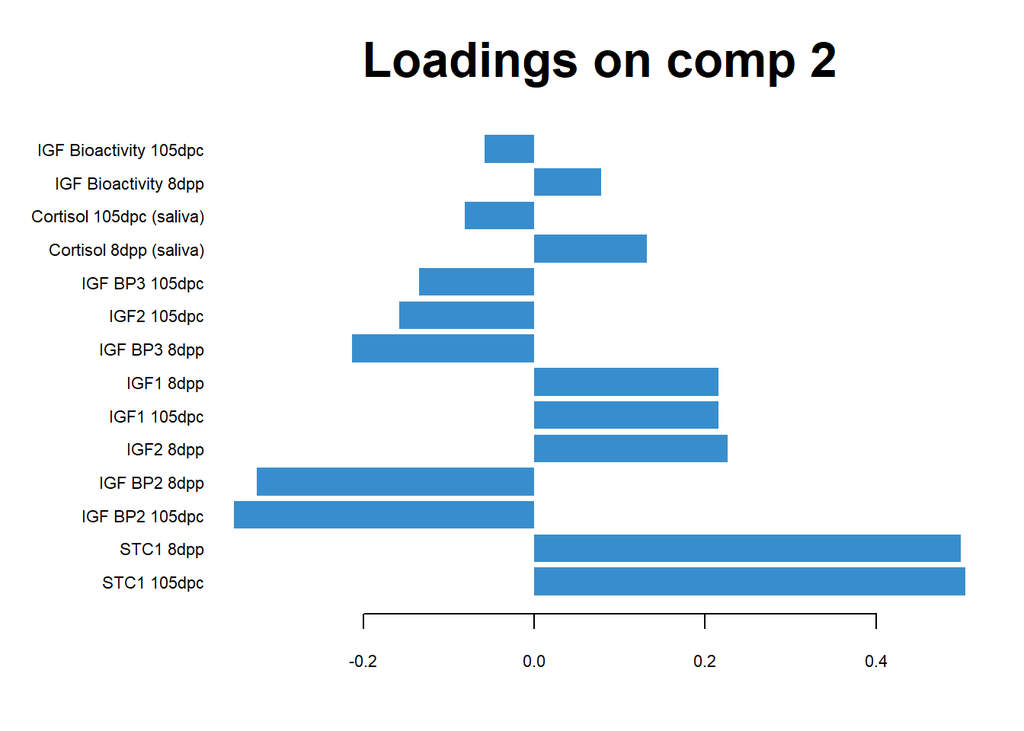

```r
plotLoadings(pca.imp, comp = 2)
```

## 7.3 Plot loadings

Prepare data frame:

```r
load.ori <- bind_cols(as_tibble(pca.ori$loadings$X),
                      as_tibble(pca.ori$names$X)) |>
  rename(parameter = value) |>
  dplyr::select(parameter, PC1, PC2) |>
  pivot_longer(!parameter, names_to = "PCs", values_to = "loading") |>
  # make factors
  mutate_at(vars(parameter,
                 PCs) , ~as.factor(.)) |>
  group_by(PCs) |>
  slice_max(order_by = abs(loading), n = 5) |>
  ungroup() |>
  droplevels()

# Change order of `PCs` factor levels
load.ori$PCs <- factor(load.ori$PCs, levels = c("PC1", "PC2"))
# Reorder `parameter` based on `PCs` (PC1 first, PC2 second)
load.ori$parameter <- factor(load.ori$parameter,
                             levels = load.ori$parameter[order(load.ori$PCs)])
```

```r
load.imp <- bind_cols(as_tibble(pca.imp$loadings$X),
                      as_tibble(pca.imp$names$X)) |>
  rename(parameter = value) |>
  dplyr::select(parameter, PC1, PC2) |>
  pivot_longer(!parameter, names_to = "PCs", values_to = "loading") |>
  # make factors
  mutate_at(vars(parameter,
                 PCs) , ~as.factor(.)) |>
  group_by(PCs) |>
  slice_max(order_by = abs(loading), n = 5) |>
  ungroup() |>
  droplevels()

# Change order of `PCs` factor levels
load.imp$PCs <- factor(load.imp$PCs, levels = c("PC1", "PC2"))
# Reorder `parameter` based on `PCs` (PC1 first, PC2 second)
load.imp$parameter <- factor(load.imp$parameter,
                             levels = load.imp$parameter[order(load.imp$PCs)])
```

Loading plots:

```r
plot.load.ori <- load.ori |>
  ggplot(aes(x = parameter, y = loading, fill = PCs)) +
  geom_bar(stat     = "identity", width = 0.7,
           position = position_identity()) +
  geom_vline(xintercept = 5.5) +
  scale_fill_manual(values = c("PC1" = "dodgerblue", "PC2" = "dodgerblue4"),
                    guide  = "none") +
  scale_x_discrete(lim = rev) +
  scale_y_continuous(lim = c(-0.55, 0.55),
                     breaks = seq(-0.5, 0.5, 0.1)) +
  labs(x    = NULL,
       y    = "Loading",
       fill = NULL) +
  geom_text(x = 1,  y = 0.4, label = "PC2",
            size = 16/.pt, color = "dodgerblue4") +
  geom_text(x = 10, y = 0.4, label = "PC1",
            size = 16/.pt, color = "dodgerblue") +
  my_theme_load +
  theme(aspect.ratio = 0.6) +
  coord_flip()
```

```r
plot.load.imp <- load.imp |>
  ggplot(aes(x = parameter, y = loading, fill = PCs)) +
  geom_bar(stat     = "identity", width = 0.7,
           position = position_identity()) +
  geom_vline(xintercept = 5.5) +
  scale_fill_manual(values = c("PC1" = "dodgerblue", "PC2" = "dodgerblue4"), guide="none") +
  scale_x_discrete(lim = rev) +
  scale_y_continuous(lim = c(-0.55, 0.55),
                     breaks = seq(-0.5, 0.5, 0.1)) +
  labs(x    = NULL,
       y    = "Loading",
       fill = NULL) +
  geom_text(x = 1,  y = 0.4, label = "PC2",
            size = 16/.pt, color = "dodgerblue4") +
  geom_text(x = 10, y = 0.4, label = "PC1",
            size = 16/.pt, color = "dodgerblue") +
  my_theme_load +
  theme(aspect.ratio = 0.6) +
  coord_flip()
```